# Task 3 - Dataset Understanding, Cleaning and Descriptive Analysis

Retail Product Demand Analysis at Fragceylon

IT3081 Statistical Modelling

21 September 2026

# 1 1. Purpose of Task 3

Task 3 prepares the Fragceylon sales data for statistical modelling and provides the descriptive evidence needed to understand the demand pattern before inferential or predictive modelling.

The analysis has two parts:

1. **Task 3A - Dataset audit and cleaning**
2. **Task 3B - Descriptive analysis and business insights**

The main demand variable is **Quantity on Regular Order rows**. Free Sample rows are retained in the cleaned master dataset but are not treated as commercial demand.

# 2 2. Raw Dataset

## 2.1 2.1 Load the raw workbook

```
raw_file = "03_Raw_Data/Fragceylon_Sales_Dataset.xlsx"

excel_sheets(raw_file)
```

```
[1] "Sales Data" "Summary"
```

```
raw_df = read_excel(
  raw_file,
  sheet = "Sales Data"
)

dim(raw_df)
```

```
[1] 5481   11
```

```
head(raw_df)
```

| Order ID | Date | Product Name | Product Code | Channel Type | Buyer | Line Type | Quantity | Unit Price (LKR) | Total Value (LKR) | Export Market |
| --- | --- | --- | --- | --- | --- | --- | --- | --- | --- | --- |
| FC-00001 | 2024-10-18 | Kennedy | 003B | Shop | Shop_04 | Regular Order | 23 | 450 | 10350 | Local |
| FC-00002 | 2024-10-18 | Secret Ambrosia | 008A | Shop | Shop_02 | Regular Order | 31 | 450 | 13950 | Local |
| FC-00003 | 2024-10-18 | Mesmerose | 006B | Shop | Shop_15 | Regular Order | 35 | 450 | 15750 | Local |
| FC-00004 | 2024-10-20 | Mesmerose | 006B | Shop | Shop_23 | Regular Order | 34 | 450 | 15300 | Local |
| FC-00005 | 2024-10-20 | Kennedy | 003B | Small Dealer | Ruwan Beauty Studio Gampaha | Regular Order | 118 | 348 | 41064 | Local |
| FC-00006 | 2024-10-20 | Kennedy | 003B | Small Dealer | Ruwan Beauty Studio Gampaha | Free Sample | 1 | 450 | 0 | Local |

## 2.2 2.2 Why inspect the raw structure?

Before analysis, we need to verify:

- the number of observations and variables;
- the data type of each variable;
- missing values;
- duplicate records;
- whether the response variable is numerically valid;
- whether business-specific record types such as Free Samples need separate treatment.

```
str(raw_df)
```

```
tibble [5,481 × 11] (S3: tbl_df/tbl/data.frame)
 $ Order ID         : chr [1:5481] "FC-00001" "FC-00002" "FC-00003" "FC-00004" ...
 $ Date             : POSIXct[1:5481], format: "2024-10-18" "2024-10-18" "2024-10-18" "2024-10-20" ...
 $ Product Name     : chr [1:5481] "Kennedy" "Secret Ambrosia" "Mesmerose" "Mesmerose" ...
 $ Product Code     : chr [1:5481] "003B" "008A" "006B" "006B" ...
 $ Channel Type     : chr [1:5481] "Shop" "Shop" "Shop" "Shop" ...
 $ Buyer            : chr [1:5481] "Shop_04" "Shop_02" "Shop_15" "Shop_23" ...
 $ Line Type        : chr [1:5481] "Regular Order" "Regular Order" "Regular Order" "Regular Order" ...
 $ Quantity         : num [1:5481] 23 31 35 34 118 1 33 66 1 72 ...
 $ Unit Price (LKR) : num [1:5481] 450 450 450 450 348 450 450 450 450 450 ...
 $ Total Value (LKR): num [1:5481] 10350 13950 15750 15300 41064 ...
 $ Export Market    : chr [1:5481] "Local" "Local" "Local" "Local" ...
```

```
summary(raw_df)
```

```
   Order ID              Date                     Product Name       Product Code       Channel Type
 Length:5481        Min.   :2024-10-18 00:00:00   Length:5481        Length:5481        Length:5481
 Class :character   1st Qu.:2025-03-16 00:00:00   Class :character   Class :character   Class :character
 Mode  :character   Median :2025-11-28 00:00:00   Mode  :character   Mode  :character   Mode  :character
                    Mean   :2025-09-05 01:39:34
                    3rd Qu.:2026-01-26 00:00:00
                    Max.   :2026-06-30 00:00:00
    Buyer            Line Type            Quantity     Unit Price (LKR) Total Value (LKR) Export Market
 Length:5481        Length:5481        Min.   :  1.0   Min.   :330.6    Min.   :     0    Length:5481
 Class :character   Class :character   1st Qu.:  1.0   1st Qu.:348.0    1st Qu.:     0    Class :character
 Mode  :character   Mode  :character   Median : 30.0   Median :380.0    Median : 13050    Mode  :character
                                       Mean   :129.2   Mean   :378.9    Mean   : 45012
                                       3rd Qu.:234.0   3rd Qu.:380.0    3rd Qu.: 80736
                                       Max.   :998.0   Max.   :450.0    Max.   :347304
```

# 3 3. Task 3A - Dataset Audit and Cleaning

## 3.1 3.1 Dataset dimensions and variables

```
cat("Rows:", nrow(raw_df), "\n")
```

```
Rows: 5481
```

```
cat("Columns:", ncol(raw_df), "\n")
```

```
Columns: 11
```

```
names(raw_df)
```

```
 [1] "Order ID"          "Date"              "Product Name"      "Product Code"      "Channel Type"
 [6] "Buyer"             "Line Type"         "Quantity"          "Unit Price (LKR)"  "Total Value (LKR)"
[11] "Export Market"
```

**Expected project result:** 5,481 rows and 11 original variables.

## 3.2 3.2 Missing-value check

**Why this check is required:** Missing values can reduce the usable sample size and may bias statistical results if they are not handled appropriately.

```
missing_by_variable = colSums(is.na(raw_df))

missing_by_variable
```

```
         Order ID              Date      Product Name      Product Code      Channel Type             Buyer
                0                 0                 0                 0                 0                 0
        Line Type          Quantity  Unit Price (LKR) Total Value (LKR)     Export Market
                0                 0                 0                 0                 0
```

```
cat("Total missing values:", sum(missing_by_variable), "\n")
```

```
Total missing values: 0
```

**Interpretation:** The project dataset contains no missing values, so no imputation or row deletion is required.

## 3.3 3.3 Exact duplicate check

**Why this check is required:** Exact duplicates can incorrectly increase frequencies, totals and apparent sample size.

```
exact_duplicate_count = sum(duplicated(raw_df))
cat("Exact duplicate rows:", exact_duplicate_count, "\n")
```

```
Exact duplicate rows: 0
```

**Interpretation:** No exact duplicate rows were found.

## 3.4 3.4 Order ID integrity

```
cat("Unique Order IDs:", length(unique(raw_df$`Order ID`)), "\n")
```

```
Unique Order IDs: 5481
```

```
cat("Duplicate Order IDs:", sum(duplicated(raw_df$`Order ID`)), "\n")
```

```
Duplicate Order IDs: 0
```

**Interpretation:** Order IDs are unique, so every row represents a distinct recorded line/order identifier.

## 3.5 3.5 Product coverage

```
table(raw_df$`Product Name`)
```

```
    Dark Matrix         Kennedy       Mesmerose Secret Ambrosia
           1185            1505            1692            1099
```

```
table(raw_df$`Product Code`)
```

```
003B 006B 008A 009A
1505 1692 1099 1185
```

The four perfumes included in this project are:

- Dark Matrix
- Kennedy
- Mesmerose
- Secret Ambrosia

## 3.6 3.6 Line Type analysis

**Why this matters:** Free Samples have a different business meaning from Regular Orders. Including free samples in demand modelling would mix promotional activity with actual commercial demand.

```
table(raw_df$`Line Type`)
```

```
  Free Sample Regular Order
         2365          3116
```

## 3.7 3.7 Free Sample validation

```
sample_df_raw = raw_df[
  raw_df$`Line Type` == "Free Sample",
]

summary(sample_df_raw$Quantity)
```

```
   Min. 1st Qu.  Median    Mean 3rd Qu.    Max.
      1       1       1       1       1       1
```

```
summary(sample_df_raw$`Total Value (LKR)`)
```

```
   Min. 1st Qu.  Median    Mean 3rd Qu.    Max.
      0       0       0       0       0       0
```

```
cat(
  "All Free Samples have Quantity = 1:",
  all(sample_df_raw$Quantity == 1),
  "\n"
)
```

```
All Free Samples have Quantity = 1: TRUE
```

```
cat(
  "All Free Samples have Total Value = 0:",
  all(sample_df_raw$`Total Value (LKR)` == 0),
  "\n"
)
```

```
All Free Samples have Total Value = 0: TRUE
```

**Interpretation:** Free Samples are structurally different from paid orders and are separated from the commercial-demand modelling population.

## 3.8 3.8 Regular Order validation

```
regular_df_raw = raw_df[
  raw_df$`Line Type` == "Regular Order",
]

summary(regular_df_raw$Quantity)
```

```
   Min. 1st Qu.  Median    Mean 3rd Qu.    Max.
   23.0    55.0   199.5   226.5   354.0   998.0
```

```
cat(
  "Commercial demand:",
  sum(regular_df_raw$Quantity),
  "\n"
)
```

```
Commercial demand: 705810
```

```
cat(
  "Regular-order revenue (LKR):",
  formatC(
    sum(regular_df_raw$`Total Value (LKR)`),
    format = "f",
    digits = 2,
    big.mark = ","
  ),
  "\n"
)
```

```
Regular-order revenue (LKR): 246,708,257.80
```

## 3.9 3.9 Price and total-value validation

**Why this check is required:** Total Value is derived from Quantity and Unit Price. The relationship should be validated before using the data.

```
regular_total_check =
  abs(
    regular_df_raw$`Total Value (LKR)` -
    regular_df_raw$Quantity * regular_df_raw$`Unit Price (LKR)`
  )

cat(
  "Regular rows with total-value mismatch:",
  sum(regular_total_check > 0.01),
  "\n"
)
```

```
Regular rows with total-value mismatch: 0
```

```
sort(unique(raw_df$`Unit Price (LKR)`))
```

```
[1] 330.6 348.0 361.0 380.0 427.5 450.0
```

**Important modelling decision:** `Total Value (LKR)` is not used as a predictor of Quantity because it directly contains Quantity and would create target leakage.

## 3.10 3.10 Date range

```
raw_df$Date = as.Date(raw_df$Date)

cat("Start date:", format(min(raw_df$Date)), "\n")
```

```
Start date: 2024-10-18
```

```
cat("End date:", format(max(raw_df$Date)), "\n")
```

```
End date: 2026-06-30
```

```
cat("Recorded transaction dates:", length(unique(raw_df$Date)), "\n")
```

```
Recorded transaction dates: 474
```

## 3.11 3.11 Structural change in sales channel

**Why this matters:** The sales structure changes on 1 April 2025. Before that date, Shop and Small Dealer transactions appear; after that date, the data are Main Dealer transactions. Therefore Channel Type and the business regime are strongly confounded.

```
regime = ifelse(
  raw_df$Date < as.Date("2025-04-01"),
  "Pre-April-2025",
  "Post-April-2025"
)

table(regime, raw_df$`Channel Type`)
```

```
regime            Main Dealer Shop Small Dealer
  Post-April-2025        4028    0            0
  Pre-April-2025            0  751          702
```

**Interpretation:** Comparisons across the whole time period must account for this structural change. It would be misleading to interpret Channel Type as a simple causal driver without considering time/regime.

## 3.12 3.12 IQR outlier detection for Regular Order Quantity

**Why use the IQR rule?** The IQR rule is a simple non-parametric method that flags unusually high or low values without assuming normality.

```
Q1 = quantile(regular_df_raw$Quantity, 0.25)
Q3 = quantile(regular_df_raw$Quantity, 0.75)
IQR_value = IQR(regular_df_raw$Quantity)

lower_fence = Q1 - 1.5 * IQR_value
upper_fence = Q3 + 1.5 * IQR_value

outlier_flag =
  regular_df_raw$Quantity < lower_fence |
  regular_df_raw$Quantity > upper_fence

cat("Q1:", Q1, "\n")
```

```
Q1: 55
```

```
cat("Q3:", Q3, "\n")
```

```
Q3: 354
```

```
cat("IQR:", IQR_value, "\n")
```

```
IQR: 299
```

```
cat("Lower fence:", lower_fence, "\n")
```

```
Lower fence: -393.5
```

```
cat("Upper fence:", upper_fence, "\n")
```

```
Upper fence: 802.5
```

```
cat("IQR outliers:", sum(outlier_flag), "\n")
```

```
IQR outliers: 41
```

```
summary(regular_df_raw$Quantity[outlier_flag])
```

```
   Min. 1st Qu.  Median    Mean 3rd Qu.    Max.
  810.0   877.0   901.0   913.5   968.0   998.0
```

**Interpretation:** The high-volume observations are valid recorded transactions rather than confirmed data-entry errors, so they are retained. Removing them only because they are large would discard real business demand.

# 4 4. Derived Variables Used in Later Tasks

The cleaned project dataset contains additional variables for descriptive, inferential and predictive analysis.

```
cleaned_file = "04_Cleaned_Data/Fragceylon_Cleaned_Master.xlsx"
regular_file = "04_Cleaned_Data/Fragceylon_Regular_Orders.xlsx"
sample_file = "04_Cleaned_Data/Fragceylon_Free_Samples.xlsx"

cleaned_master = read_excel(cleaned_file)
regular_orders = read_excel(regular_file)
free_samples = read_excel(sample_file)

cleaned_master$Date = as.Date(cleaned_master$Date)
regular_orders$Date = as.Date(regular_orders$Date)
free_samples$Date = as.Date(free_samples$Date)

dim(cleaned_master)
```

```
[1] 5481   22
```

```
dim(regular_orders)
```

```
[1] 3116   22
```

```
dim(free_samples)
```

```
[1] 2365   22
```

```
names(cleaned_master)
```

```
 [1] "Order ID"          "Date"              "Product Name"      "Product Code"      "Channel Type"
 [6] "Buyer"             "Line Type"         "Quantity"          "Unit Price (LKR)"  "Total Value (LKR)"
[11] "Export Market"     "Outlier_IQR_Flag"  "Year"              "Month"             "Month_Number"
[16] "Quarter"           "Day_of_Week"       "Year_Month"        "Time_Trend"        "Sales_Regime"
[21] "Is_Regular_Order"  "Market_Group"
```

Key derived variables include:

- Year
- Month
- Month Number
- Quarter
- Day of Week
- Year-Month
- Time Trend
- Sales Regime
- Is Regular Order
- Market Group
- IQR Outlier Flag

# 5 5. Cleaning Validation Summary

```
validation = data.frame(
  Check = c(
    "Cleaned master rows",
    "Regular Order rows",
    "Free Sample rows",
    "Missing values",
    "Commercial demand",
    "IQR high outliers"
  ),
  Result = c(
    nrow(cleaned_master),
    nrow(regular_orders),
    nrow(free_samples),
    sum(is.na(cleaned_master)),
    sum(regular_orders$Quantity),
    sum(regular_orders$Outlier_IQR_Flag == "Yes")
  )
)

kable(validation, caption = "Task 3A Cleaning Validation")
```

Task 3A Cleaning Validation

| Check | Result |
| --- | --- |
| Cleaned master rows | 5481 |
| Regular Order rows | 3116 |
| Free Sample rows | 2365 |
| Missing values | 0 |
| Commercial demand | 705810 |
| IQR high outliers | 41 |

# 6 6. Task 3B - Descriptive Analysis

## 6.1 6.1 Why descriptive analysis?

Descriptive statistics summarize the size, centre, spread and distribution of demand before formal statistical tests are performed. They also identify important business patterns that should guide model specification.

## 6.2 6.2 Overall Regular Order Quantity

```
quantity_stats = data.frame(
  Measure = c(
    "N",
    "Mean",
    "Median",
    "Standard Deviation",
    "Variance",
    "Minimum",
    "Q1",
    "Q3",
    "Maximum"
  ),
  Value = c(
    length(regular_orders$Quantity),
    mean(regular_orders$Quantity),
    median(regular_orders$Quantity),
    sd(regular_orders$Quantity),
    var(regular_orders$Quantity),
    min(regular_orders$Quantity),
    quantile(regular_orders$Quantity, 0.25),
    quantile(regular_orders$Quantity, 0.75),
    max(regular_orders$Quantity)
  )
)

kable(
  quantity_stats,
  digits = 2,
  caption = "Overall Regular Order Quantity Statistics"
)
```

Overall Regular Order Quantity Statistics

| Measure | Value |
| --- | --- |
| N | 3116.00 |
| Mean | 226.51 |
| Median | 199.50 |
| Standard Deviation | 183.88 |
| Variance | 33811.18 |
| Minimum | 23.00 |
| Q1 | 55.00 |
| Q3 | 354.00 |
| Maximum | 998.00 |

**Project result:** Mean Quantity is about 226.51 units, while the median is 199.5 units. The maximum is 998 units.

## 6.3 6.3 Quantity distribution

```
hist(
  regular_orders$Quantity,
  main = "Distribution of Regular Order Quantity",
  xlab = "Quantity",
  ylab = "Frequency",
  breaks = 30
)
```

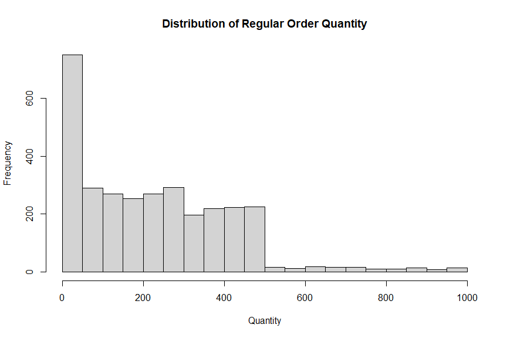

**Interpretation:** Quantity is widely dispersed and includes a small set of very large commercial orders.

## 6.4 6.4 Product-level demand

```
product_total = aggregate(
  Quantity ~ `Product Name`,
  data = regular_orders,
  FUN = sum
)

product_mean = aggregate(
  Quantity ~ `Product Name`,
  data = regular_orders,
  FUN = mean
)

product_n = aggregate(
  Quantity ~ `Product Name`,
  data = regular_orders,
  FUN = length
)

names(product_total)[2] = "Total_Demand"
names(product_mean)[2] = "Mean_Order_Quantity"
names(product_n)[2] = "Number_of_Orders"

product_summary = merge(
  merge(product_total, product_mean, by = "Product Name"),
  product_n,
  by = "Product Name"
)

product_summary = product_summary[
  order(product_summary$Total_Demand, decreasing = TRUE),
]

kable(
  product_summary,
  digits = 2,
  caption = "Demand by Product"
)
```

Demand by Product

|  | Product Name | Total_Demand | Mean_Order_Quantity | Number_of_Orders |
| --- | --- | --- | --- | --- |
| 3 | Mesmerose | 215866 | 221.40 | 975 |
| 2 | Kennedy | 193932 | 227.89 | 851 |
| 1 | Dark Matrix | 154120 | 230.03 | 670 |
| 4 | Secret Ambrosia | 141892 | 228.86 | 620 |

```
barplot(
  product_summary$Total_Demand,
  names.arg = product_summary$`Product Name`,
  main = "Total Demand by Product",
  xlab = "Product",
  ylab = "Total Quantity",
  las = 2
)
```

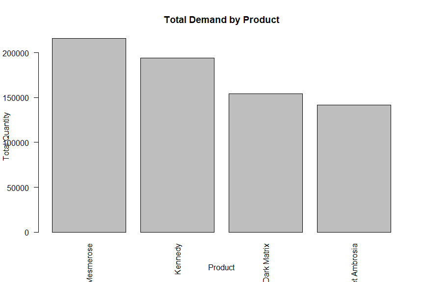

**Business insight:** Mesmerose records the highest total commercial demand in the observed period. Dark Matrix has the highest average order size. Total demand and average transaction size are different business measures and should not be confused.

## 6.5 6.5 Channel-level demand

```
channel_summary = aggregate(
  Quantity ~ `Channel Type`,
  data = regular_orders,
  FUN = sum
)

channel_summary = channel_summary[
  order(channel_summary$Quantity, decreasing = TRUE),
]

kable(
  channel_summary,
  caption = "Total Demand by Channel"
)
```

Total Demand by Channel

|  | Channel Type | Quantity |
| --- | --- | --- |
| 1 | Main Dealer | 622595 |
| 3 | Small Dealer | 60766 |
| 2 | Shop | 22449 |

**Caution:** Channel results are strongly affected by the structural change on 1 April 2025. Channel differences should not be interpreted as causal effects across the full period.

## 6.6 6.6 Export market demand

```
market_summary = aggregate(
  Quantity ~ `Export Market`,
  data = regular_orders,
  FUN = sum
)

kable(
  market_summary,
  caption = "Total Demand by Export Market"
)
```

Total Demand by Export Market

| Export Market | Quantity |
| --- | --- |
| Japan | 115168 |
| Local | 590642 |

**Caution:** Japan transactions are concentrated in the Main Dealer structure and in one buyer. The Japan indicator is therefore an important association but not a standalone causal market effect.

## 6.7 6.7 Monthly demand trend

```
monthly_summary = aggregate(
  Quantity ~ Year_Month,
  data = regular_orders,
  FUN = sum
)

monthly_summary = monthly_summary[
  order(monthly_summary$Year_Month),
]

kable(
  monthly_summary,
  caption = "Monthly Commercial Demand"
)
```

Monthly Commercial Demand

| Year_Month | Quantity |
| --- | --- |
| 2024-10 | 1556 |
| 2024-11 | 12044 |
| 2024-12 | 28450 |
| 2025-01 | 27557 |
| 2025-02 | 3717 |
| 2025-03 | 9891 |
| 2025-04 | 103212 |
| 2025-05 | 13588 |
| 2025-06 | 7119 |
| 2025-07 | 2983 |
| 2025-08 | 7002 |
| 2025-09 | 11286 |
| 2025-10 | 12086 |
| 2025-11 | 49323 |
| 2025-12 | 115818 |
| 2026-01 | 106387 |
| 2026-02 | 17899 |
| 2026-03 | 43471 |
| 2026-04 | 107546 |
| 2026-05 | 12241 |
| 2026-06 | 12634 |

```
plot(
  seq_len(nrow(monthly_summary)),
  monthly_summary$Quantity,
  type = "o",
  xaxt = "n",
  main = "Monthly Commercial Demand",
  xlab = "Year-Month",
  ylab = "Total Quantity"
)

axis(
  1,
  at = seq_len(nrow(monthly_summary)),
  labels = monthly_summary$Year_Month,
  las = 2,
  cex.axis = 0.7
)
```

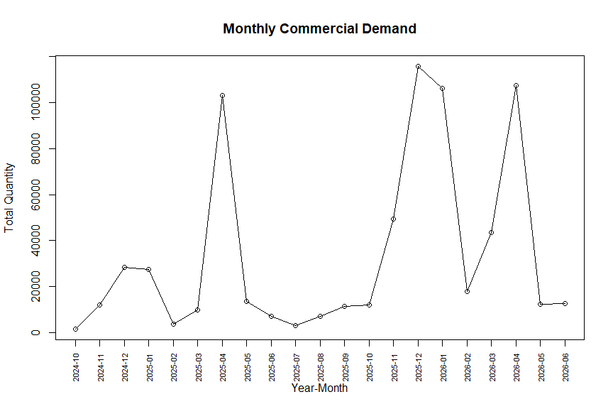

**Business insight:** December 2025 has the largest observed monthly total demand. October 2024 is only a partial first month because the dataset begins on 18 October 2024, so it should not be treated as a full-month comparison.

## 6.8 6.8 Revenue by product

```
revenue_product = aggregate(
  `Total Value (LKR)` ~ `Product Name`,
  data = regular_orders,
  FUN = sum
)

revenue_product = revenue_product[
  order(revenue_product$`Total Value (LKR)`, decreasing = TRUE),
]

kable(
  revenue_product,
  digits = 2,
  caption = "Regular Order Revenue by Product"
)
```

Regular Order Revenue by Product

|  | Product Name | Total Value (LKR) |
| --- | --- | --- |
| 3 | Mesmerose | 75529325 |
| 2 | Kennedy | 67786470 |
| 1 | Dark Matrix | 53821303 |
| 4 | Secret Ambrosia | 49571160 |

# 7 7. Task 3 Main Findings

The dataset is suitable for statistical modelling after separating Regular Orders from Free Samples. There are no missing values or exact duplicate rows. Commercial demand equals **705,810 units**, and Regular Order revenue equals approximately **LKR 246.71 million**.

The IQR method identifies 41 high-volume transactions, but these were retained because they are valid business records. A major structural change occurs on **1 April 2025**, after which all observed transactions are Main Dealer records. This change is important for Task 4 inference and Task 5 predictive modelling.

# 8 8. Task 3 Limitations

- The dataset contains transaction-level records, not a complete measure of all possible market demand.
- The first month, October 2024, is partial.
- Channel Type is confounded with the pre/post April 2025 operating regime.
- Japan records are structurally concentrated in one buyer.
- Descriptive differences are associations and do not establish causality.